# Optimal Treatment Analysis

## Outcome Variable

**Outcome Variable:** ever_stunted

## Predictor Variables

**Intervention Variable:** hfoodsec

**Adjustment Set:**

- arm
- sex
- W_mage
- meducyrs
- feducyrs
- hhwealth_quart
- vagbrth
- W_nrooms
- W_nchldlt5
- brthmon
- W_parity
- impfloor
- impsan
- safeh20
- delta_W_mage
- delta_meducyrs
- delta_feducyrs
- delta_hhwealth_quart
- delta_vagbrth
- delta_W_nrooms
- delta_W_nchldlt5
- delta_brthmon
- delta_W_parity
- delta_impfloor
- delta_impsan
- delta_safeh20

## Stratifying Variables

The analysis was stratified on these variable(s):

- agecat
- studyid
- country

## Data Summary

| agecat | studyid | country | hfoodsec | ever_stunted | n_cell | n |
| --- | --- | --- | --- | --- | --- | --- |
| 0-24 months | ki0047075b-MAL-ED | BANGLADESH | Food Secure | 0 | 62 | 194 |
| 0-24 months | ki0047075b-MAL-ED | BANGLADESH | Food Secure | 1 | 99 | 194 |
| 0-24 months | ki0047075b-MAL-ED | BANGLADESH | Mildly Food Insecure | 0 | 1 | 194 |
| 0-24 months | ki0047075b-MAL-ED | BANGLADESH | Mildly Food Insecure | 1 | 3 | 194 |
| 0-24 months | ki0047075b-MAL-ED | BANGLADESH | Food Insecure | 0 | 10 | 194 |
| 0-24 months | ki0047075b-MAL-ED | BANGLADESH | Food Insecure | 1 | 19 | 194 |
| 0-24 months | ki0047075b-MAL-ED | BRAZIL | Food Secure | 0 | 3 | 129 |
| 0-24 months | ki0047075b-MAL-ED | BRAZIL | Food Secure | 1 | 0 | 129 |
| 0-24 months | ki0047075b-MAL-ED | BRAZIL | Mildly Food Insecure | 0 | 7 | 129 |
| 0-24 months | ki0047075b-MAL-ED | BRAZIL | Mildly Food Insecure | 1 | 4 | 129 |
| 0-24 months | ki0047075b-MAL-ED | BRAZIL | Food Insecure | 0 | 90 | 129 |
| 0-24 months | ki0047075b-MAL-ED | BRAZIL | Food Insecure | 1 | 25 | 129 |
| 0-24 months | ki0047075b-MAL-ED | INDIA | Food Secure | 0 | 67 | 212 |
| 0-24 months | ki0047075b-MAL-ED | INDIA | Food Secure | 1 | 123 | 212 |
| 0-24 months | ki0047075b-MAL-ED | INDIA | Mildly Food Insecure | 0 | 5 | 212 |
| 0-24 months | ki0047075b-MAL-ED | INDIA | Mildly Food Insecure | 1 | 0 | 212 |
| 0-24 months | ki0047075b-MAL-ED | INDIA | Food Insecure | 0 | 7 | 212 |
| 0-24 months | ki0047075b-MAL-ED | INDIA | Food Insecure | 1 | 10 | 212 |
| 0-24 months | ki0047075b-MAL-ED | NEPAL | Food Secure | 0 | 63 | 128 |
| 0-24 months | ki0047075b-MAL-ED | NEPAL | Food Secure | 1 | 31 | 128 |
| 0-24 months | ki0047075b-MAL-ED | NEPAL | Mildly Food Insecure | 0 | 9 | 128 |
| 0-24 months | ki0047075b-MAL-ED | NEPAL | Mildly Food Insecure | 1 | 6 | 128 |
| 0-24 months | ki0047075b-MAL-ED | NEPAL | Food Insecure | 0 | 9 | 128 |
| 0-24 months | ki0047075b-MAL-ED | NEPAL | Food Insecure | 1 | 10 | 128 |
| 0-24 months | ki0047075b-MAL-ED | PERU | Food Secure | 0 | 6 | 113 |
| 0-24 months | ki0047075b-MAL-ED | PERU | Food Secure | 1 | 21 | 113 |
| 0-24 months | ki0047075b-MAL-ED | PERU | Mildly Food Insecure | 0 | 8 | 113 |
| 0-24 months | ki0047075b-MAL-ED | PERU | Mildly Food Insecure | 1 | 21 | 113 |
| 0-24 months | ki0047075b-MAL-ED | PERU | Food Insecure | 0 | 17 | 113 |
| 0-24 months | ki0047075b-MAL-ED | PERU | Food Insecure | 1 | 40 | 113 |

[output cut: 168 more lines]

The following strata were considered:

- agecat: 0-24 months, studyid: ki0047075b-MAL-ED, country: BANGLADESH
- agecat: 0-24 months, studyid: ki0047075b-MAL-ED, country: BRAZIL
- agecat: 0-24 months, studyid: ki0047075b-MAL-ED, country: INDIA
- agecat: 0-24 months, studyid: ki0047075b-MAL-ED, country: NEPAL
- agecat: 0-24 months, studyid: ki0047075b-MAL-ED, country: PERU
- agecat: 0-24 months, studyid: ki0047075b-MAL-ED, country: SOUTH AFRICA
- agecat: 0-24 months, studyid: ki1017093-NIH-Birth, country: BANGLADESH
- agecat: 0-24 months, studyid: ki1017093c-NIH-Crypto, country: BANGLADESH
- agecat: 0-24 months, studyid: ki1113344-GMS-Nepal, country: NEPAL
- agecat: 0-24 months, studyid: kiGH5241-JiVitA-3, country: BANGLADESH
- agecat: 0-24 months, studyid: kiGH5241-JiVitA-4, country: BANGLADESH
- agecat: 0-6 months, studyid: ki0047075b-MAL-ED, country: BANGLADESH
- agecat: 0-6 months, studyid: ki0047075b-MAL-ED, country: BRAZIL
- agecat: 0-6 months, studyid: ki0047075b-MAL-ED, country: INDIA
- agecat: 0-6 months, studyid: ki0047075b-MAL-ED, country: NEPAL
- agecat: 0-6 months, studyid: ki0047075b-MAL-ED, country: PERU
- agecat: 0-6 months, studyid: ki0047075b-MAL-ED, country: SOUTH AFRICA
- agecat: 0-6 months, studyid: ki1017093-NIH-Birth, country: BANGLADESH
- agecat: 0-6 months, studyid: ki1017093c-NIH-Crypto, country: BANGLADESH
- agecat: 0-6 months, studyid: ki1113344-GMS-Nepal, country: NEPAL
- agecat: 0-6 months, studyid: kiGH5241-JiVitA-3, country: BANGLADESH
- agecat: 0-6 months, studyid: kiGH5241-JiVitA-4, country: BANGLADESH
- agecat: 6-24 months, studyid: ki0047075b-MAL-ED, country: BANGLADESH
- agecat: 6-24 months, studyid: ki0047075b-MAL-ED, country: BRAZIL
- agecat: 6-24 months, studyid: ki0047075b-MAL-ED, country: INDIA
- agecat: 6-24 months, studyid: ki0047075b-MAL-ED, country: NEPAL
- agecat: 6-24 months, studyid: ki0047075b-MAL-ED, country: PERU
- agecat: 6-24 months, studyid: ki0047075b-MAL-ED, country: SOUTH AFRICA
- agecat: 6-24 months, studyid: ki1017093-NIH-Birth, country: BANGLADESH
- agecat: 6-24 months, studyid: ki1017093c-NIH-Crypto, country: BANGLADESH
- agecat: 6-24 months, studyid: ki1113344-GMS-Nepal, country: NEPAL
- agecat: 6-24 months, studyid: kiGH5241-JiVitA-3, country: BANGLADESH
- agecat: 6-24 months, studyid: kiGH5241-JiVitA-4, country: BANGLADESH

### Dropped Strata

Some strata were dropped due to rare outcomes:

- agecat: 0-24 months, studyid: ki0047075b-MAL-ED, country: BANGLADESH
- agecat: 0-24 months, studyid: ki0047075b-MAL-ED, country: BRAZIL
- agecat: 0-24 months, studyid: ki0047075b-MAL-ED, country: INDIA
- agecat: 0-6 months, studyid: ki0047075b-MAL-ED, country: BANGLADESH
- agecat: 0-6 months, studyid: ki0047075b-MAL-ED, country: BRAZIL
- agecat: 0-6 months, studyid: ki0047075b-MAL-ED, country: INDIA
- agecat: 0-6 months, studyid: ki0047075b-MAL-ED, country: NEPAL
- agecat: 0-6 months, studyid: ki0047075b-MAL-ED, country: SOUTH AFRICA
- agecat: 6-24 months, studyid: ki0047075b-MAL-ED, country: BANGLADESH
- agecat: 6-24 months, studyid: ki0047075b-MAL-ED, country: BRAZIL
- agecat: 6-24 months, studyid: ki0047075b-MAL-ED, country: INDIA
- agecat: 6-24 months, studyid: ki0047075b-MAL-ED, country: NEPAL

## Methods Detail

We’re interested in the causal parameters $E[Y_a]$ for all values of $a \in \mathcal{A}$. These parameters represent the mean outcome if, possibly contrary to fact, we intervened to set all units to have $A=a$. Under the randomization and positivity assumptions, these are identified by the statistical parameters $\psi_a=E_W[E_{Y|A,W}(Y|A=a,W)]$. In addition, we’re interested in the mean of $Y$, $E[Y]$ under no intervention (the observed mean). We will estimate these parameters by using SuperLearner to fit the relevant likelihood factors – $E_{Y|A,W}(Y|A=a,W)$ and $p(A=a|W)$, and then updating our likelihood fit using a joint TMLE.

For unadjusted analyses ($W=\{\}$), initial likelihoods were estimated using Lrnr_glm to estimate the simple $E(Y|A)$ and Lrnr_mean to estimate $p(A)$. For adjusted analyses, a small library containing Lrnr_glmnet, Lrnr_xgboost, and Lrnr_mean was used.

Having estimated these parameters, we will then use the delta method to estimate relative risks and attributable risks relative to a prespecified baseline level of $A$.

# Results Detail

## Results Plots

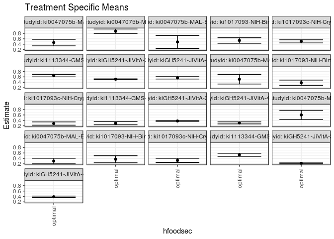

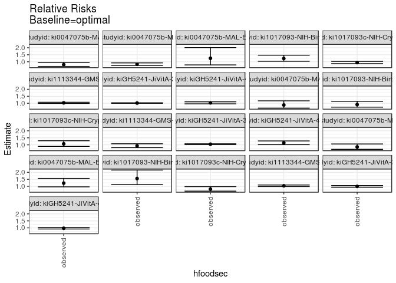

## Results Table

### Parameter: TSM

| agecat | studyid | country | intervention_level | baseline_level | estimate | ci_lower | ci_upper |
| --- | --- | --- | --- | --- | --- | --- | --- |
| 0-24 months | ki0047075b-MAL-ED | NEPAL | optimal | NA | 0.4622206 | 0.3418421 | 0.5825992 |
| 0-24 months | ki0047075b-MAL-ED | PERU | optimal | NA | 0.8804272 | 0.8000934 | 0.9607611 |
| 0-24 months | ki0047075b-MAL-ED | SOUTH AFRICA | optimal | NA | 0.4843045 | 0.2440686 | 0.7245404 |
| 0-24 months | ki1017093-NIH-Birth | BANGLADESH | optimal | NA | 0.5387369 | 0.4366237 | 0.6408501 |
| 0-24 months | ki1017093c-NIH-Crypto | BANGLADESH | optimal | NA | 0.5063508 | 0.4488297 | 0.5638719 |
| 0-24 months | ki1113344-GMS-Nepal | NEPAL | optimal | NA | 0.6477115 | 0.6009159 | 0.6945072 |
| 0-24 months | kiGH5241-JiVitA-3 | BANGLADESH | optimal | NA | 0.5145883 | 0.5019175 | 0.5272591 |
| 0-24 months | kiGH5241-JiVitA-4 | BANGLADESH | optimal | NA | 0.5644016 | 0.5209393 | 0.6078639 |
| 0-6 months | ki0047075b-MAL-ED | PERU | optimal | NA | 0.5143839 | 0.3363356 | 0.6924323 |
| 0-6 months | ki1017093-NIH-Birth | BANGLADESH | optimal | NA | 0.3845205 | 0.2877750 | 0.4812659 |
| 0-6 months | ki1017093c-NIH-Crypto | BANGLADESH | optimal | NA | 0.2824159 | 0.2218389 | 0.3429929 |
| 0-6 months | ki1113344-GMS-Nepal | NEPAL | optimal | NA | 0.2953301 | 0.2372960 | 0.3533642 |
| 0-6 months | kiGH5241-JiVitA-3 | BANGLADESH | optimal | NA | 0.3773798 | 0.3640245 | 0.3907351 |
| 0-6 months | kiGH5241-JiVitA-4 | BANGLADESH | optimal | NA | 0.3065415 | 0.2683667 | 0.3447162 |
| 6-24 months | ki0047075b-MAL-ED | PERU | optimal | NA | 0.6005317 | 0.4296952 | 0.7713682 |
| 6-24 months | ki0047075b-MAL-ED | SOUTH AFRICA | optimal | NA | 0.3032590 | 0.2009164 | 0.4056017 |
| 6-24 months | ki1017093-NIH-Birth | BANGLADESH | optimal | NA | 0.3682433 | 0.2382564 | 0.4982302 |
| 6-24 months | ki1017093c-NIH-Crypto | BANGLADESH | optimal | NA | 0.3271771 | 0.2501027 | 0.4042515 |
| 6-24 months | ki1113344-GMS-Nepal | NEPAL | optimal | NA | 0.5333267 | 0.4771178 | 0.5895357 |
| 6-24 months | kiGH5241-JiVitA-3 | BANGLADESH | optimal | NA | 0.2184312 | 0.2022358 | 0.2346265 |
| 6-24 months | kiGH5241-JiVitA-4 | BANGLADESH | optimal | NA | 0.3891043 | 0.3619348 | 0.4162737 |

### Parameter: E(Y)

| agecat | studyid | country | intervention_level | baseline_level | estimate | ci_lower | ci_upper |
| --- | --- | --- | --- | --- | --- | --- | --- |
| 0-24 months | ki0047075b-MAL-ED | NEPAL | observed | NA | 0.3671875 | 0.2833521 | 0.4510229 |
| 0-24 months | ki0047075b-MAL-ED | PERU | observed | NA | 0.7256637 | 0.6430317 | 0.8082957 |
| 0-24 months | ki0047075b-MAL-ED | SOUTH AFRICA | observed | NA | 0.6051502 | 0.5422501 | 0.6680504 |
| 0-24 months | ki1017093-NIH-Birth | BANGLADESH | observed | NA | 0.6645469 | 0.6276196 | 0.7014742 |
| 0-24 months | ki1017093c-NIH-Crypto | BANGLADESH | observed | NA | 0.4775726 | 0.4419904 | 0.5131548 |
| 0-24 months | ki1113344-GMS-Nepal | NEPAL | observed | NA | 0.6678082 | 0.6295756 | 0.7060408 |
| 0-24 months | kiGH5241-JiVitA-3 | BANGLADESH | observed | NA | 0.5232725 | 0.5136886 | 0.5328564 |
| 0-24 months | kiGH5241-JiVitA-4 | BANGLADESH | observed | NA | 0.5813264 | 0.5653125 | 0.5973403 |
| 0-6 months | ki0047075b-MAL-ED | PERU | observed | NA | 0.4513274 | 0.3591676 | 0.5434872 |
| 0-6 months | ki1017093-NIH-Birth | BANGLADESH | observed | NA | 0.3497615 | 0.3124631 | 0.3870600 |
| 0-6 months | ki1017093c-NIH-Crypto | BANGLADESH | observed | NA | 0.3021108 | 0.2694011 | 0.3348205 |
| 0-6 months | ki1113344-GMS-Nepal | NEPAL | observed | NA | 0.2739726 | 0.2377697 | 0.3101755 |
| 0-6 months | kiGH5241-JiVitA-3 | BANGLADESH | observed | NA | 0.3935789 | 0.3847652 | 0.4023927 |
| 0-6 months | kiGH5241-JiVitA-4 | BANGLADESH | observed | NA | 0.3483896 | 0.3331073 | 0.3636720 |
| 6-24 months | ki0047075b-MAL-ED | PERU | observed | NA | 0.5081967 | 0.3816986 | 0.6346949 |
| 6-24 months | ki0047075b-MAL-ED | SOUTH AFRICA | observed | NA | 0.3724138 | 0.2934521 | 0.4513755 |
| 6-24 months | ki1017093-NIH-Birth | BANGLADESH | observed | NA | 0.5739130 | 0.5216565 | 0.6261696 |
| 6-24 months | ki1017093c-NIH-Crypto | BANGLADESH | observed | NA | 0.2628458 | 0.2244546 | 0.3012371 |
| 6-24 months | ki1113344-GMS-Nepal | NEPAL | observed | NA | 0.5542169 | 0.5063374 | 0.6020964 |
| 6-24 months | kiGH5241-JiVitA-3 | BANGLADESH | observed | NA | 0.2172338 | 0.2078312 | 0.2266365 |
| 6-24 months | kiGH5241-JiVitA-4 | BANGLADESH | observed | NA | 0.3773167 | 0.3586399 | 0.3959936 |

### Parameter: RR

| agecat | studyid | country | intervention_level | baseline_level | estimate | ci_lower | ci_upper |
| --- | --- | --- | --- | --- | --- | --- | --- |
| 0-24 months | ki0047075b-MAL-ED | NEPAL | observed | optimal | 0.7943987 | 0.6631432 | 0.9516337 |
| 0-24 months | ki0047075b-MAL-ED | PERU | observed | optimal | 0.8242177 | 0.7387474 | 0.9195766 |
| 0-24 months | ki0047075b-MAL-ED | SOUTH AFRICA | observed | optimal | 1.2495242 | 0.7760011 | 2.0119954 |
| 0-24 months | ki1017093-NIH-Birth | BANGLADESH | observed | optimal | 1.2335277 | 1.0362298 | 1.4683910 |
| 0-24 months | ki1017093c-NIH-Crypto | BANGLADESH | observed | optimal | 0.9431654 | 0.8655481 | 1.0277430 |
| 0-24 months | ki1113344-GMS-Nepal | NEPAL | observed | optimal | 1.0310272 | 0.9900275 | 1.0737248 |
| 0-24 months | kiGH5241-JiVitA-3 | BANGLADESH | observed | optimal | 1.0168762 | 0.9990201 | 1.0350514 |
| 0-24 months | kiGH5241-JiVitA-4 | BANGLADESH | observed | optimal | 1.0299872 | 0.9603726 | 1.1046479 |
| 0-6 months | ki0047075b-MAL-ED | PERU | observed | optimal | 0.8774136 | 0.6551958 | 1.1749993 |
| 0-6 months | ki1017093-NIH-Birth | BANGLADESH | observed | optimal | 0.9096045 | 0.7223895 | 1.1453382 |
| 0-6 months | ki1017093c-NIH-Crypto | BANGLADESH | observed | optimal | 1.0697373 | 0.8865496 | 1.2907771 |
| 0-6 months | ki1113344-GMS-Nepal | NEPAL | observed | optimal | 0.9276826 | 0.7998051 | 1.0760060 |
| 0-6 months | kiGH5241-JiVitA-3 | BANGLADESH | observed | optimal | 1.0429253 | 1.0156402 | 1.0709434 |
| 0-6 months | kiGH5241-JiVitA-4 | BANGLADESH | observed | optimal | 1.1365172 | 1.0116811 | 1.2767573 |
| 6-24 months | ki0047075b-MAL-ED | PERU | observed | optimal | 0.8462446 | 0.6749636 | 1.0609905 |
| 6-24 months | ki0047075b-MAL-ED | SOUTH AFRICA | observed | optimal | 1.2280387 | 0.9637229 | 1.5648471 |
| 6-24 months | ki1017093-NIH-Birth | BANGLADESH | observed | optimal | 1.5585160 | 1.1226795 | 2.1635490 |
| 6-24 months | ki1017093c-NIH-Crypto | BANGLADESH | observed | optimal | 0.8033748 | 0.6592327 | 0.9790339 |
| 6-24 months | ki1113344-GMS-Nepal | NEPAL | observed | optimal | 1.0391695 | 0.9846820 | 1.0966720 |
| 6-24 months | kiGH5241-JiVitA-3 | BANGLADESH | observed | optimal | 0.9945183 | 0.9356509 | 1.0570895 |
| 6-24 months | kiGH5241-JiVitA-4 | BANGLADESH | observed | optimal | 0.9697060 | 0.9191001 | 1.0230983 |

### Parameter: PAR

| agecat | studyid | country | intervention_level | baseline_level | estimate | ci_lower | ci_upper |
| --- | --- | --- | --- | --- | --- | --- | --- |
| 0-24 months | ki0047075b-MAL-ED | NEPAL | optimal | NA | -0.0950331 | -0.1768604 | -0.0132059 |
| 0-24 months | ki0047075b-MAL-ED | PERU | optimal | NA | -0.1547635 | -0.2404122 | -0.0691148 |
| 0-24 months | ki0047075b-MAL-ED | SOUTH AFRICA | optimal | NA | 0.1208457 | -0.1091436 | 0.3508350 |
| 0-24 months | ki1017093-NIH-Birth | BANGLADESH | optimal | NA | 0.1258100 | 0.0325443 | 0.2190756 |
| 0-24 months | ki1017093c-NIH-Crypto | BANGLADESH | optimal | NA | -0.0287782 | -0.0723122 | 0.0147558 |
| 0-24 months | ki1113344-GMS-Nepal | NEPAL | optimal | NA | 0.0200967 | -0.0061382 | 0.0463316 |
| 0-24 months | kiGH5241-JiVitA-3 | BANGLADESH | optimal | NA | 0.0086843 | -0.0004440 | 0.0178125 |
| 0-24 months | kiGH5241-JiVitA-4 | BANGLADESH | optimal | NA | 0.0169248 | -0.0225418 | 0.0563914 |
| 0-6 months | ki0047075b-MAL-ED | PERU | optimal | NA | -0.0630565 | -0.2130566 | 0.0869436 |
| 0-6 months | ki1017093-NIH-Birth | BANGLADESH | optimal | NA | -0.0347589 | -0.1233589 | 0.0538410 |
| 0-6 months | ki1017093c-NIH-Crypto | BANGLADESH | optimal | NA | 0.0196949 | -0.0334466 | 0.0728364 |
| 0-6 months | ki1113344-GMS-Nepal | NEPAL | optimal | NA | -0.0213575 | -0.0651913 | 0.0224763 |
| 0-6 months | kiGH5241-JiVitA-3 | BANGLADESH | optimal | NA | 0.0161991 | 0.0062028 | 0.0261955 |
| 0-6 months | kiGH5241-JiVitA-4 | BANGLADESH | optimal | NA | 0.0418482 | 0.0061416 | 0.0775548 |
| 6-24 months | ki0047075b-MAL-ED | PERU | optimal | NA | -0.0923350 | -0.2234396 | 0.0387697 |
| 6-24 months | ki0047075b-MAL-ED | SOUTH AFRICA | optimal | NA | 0.0691548 | -0.0043546 | 0.1426642 |
| 6-24 months | ki1017093-NIH-Birth | BANGLADESH | optimal | NA | 0.2056698 | 0.0861685 | 0.3251710 |
| 6-24 months | ki1017093c-NIH-Crypto | BANGLADESH | optimal | NA | -0.0643313 | -0.1289073 | 0.0002448 |
| 6-24 months | ki1113344-GMS-Nepal | NEPAL | optimal | NA | 0.0208901 | -0.0077463 | 0.0495266 |
| 6-24 months | kiGH5241-JiVitA-3 | BANGLADESH | optimal | NA | -0.0011974 | -0.0145243 | 0.0121296 |
| 6-24 months | kiGH5241-JiVitA-4 | BANGLADESH | optimal | NA | -0.0117875 | -0.0326016 | 0.0090266 |

### Parameter: PAF

| agecat | studyid | country | intervention_level | baseline_level | estimate | ci_lower | ci_upper |
| --- | --- | --- | --- | --- | --- | --- | --- |
| 0-24 months | ki0047075b-MAL-ED | NEPAL | optimal | NA | -0.2588137 | -0.5079700 | -0.0508245 |
| 0-24 months | ki0047075b-MAL-ED | PERU | optimal | NA | -0.2132717 | -0.3536426 | -0.0874570 |
| 0-24 months | ki0047075b-MAL-ED | SOUTH AFRICA | optimal | NA | 0.1996954 | -0.2886579 | 0.5029810 |
| 0-24 months | ki1017093-NIH-Birth | BANGLADESH | optimal | NA | 0.1893169 | 0.0349631 | 0.3189825 |
| 0-24 months | ki1017093c-NIH-Crypto | BANGLADESH | optimal | NA | -0.0602594 | -0.1553373 | 0.0269941 |
| 0-24 months | ki1113344-GMS-Nepal | NEPAL | optimal | NA | 0.0300935 | -0.0100729 | 0.0686627 |
| 0-24 months | kiGH5241-JiVitA-3 | BANGLADESH | optimal | NA | 0.0165961 | -0.0009809 | 0.0338644 |
| 0-24 months | kiGH5241-JiVitA-4 | BANGLADESH | optimal | NA | 0.0291141 | -0.0412626 | 0.0947342 |
| 0-6 months | ki0047075b-MAL-ED | PERU | optimal | NA | -0.1397134 | -0.5262614 | 0.1489356 |
| 0-6 months | ki1017093-NIH-Birth | BANGLADESH | optimal | NA | -0.0993790 | -0.3842948 | 0.1268954 |
| 0-6 months | ki1017093c-NIH-Crypto | BANGLADESH | optimal | NA | 0.0651910 | -0.1279685 | 0.2252729 |
| 0-6 months | ki1113344-GMS-Nepal | NEPAL | optimal | NA | -0.0779549 | -0.2503046 | 0.0706371 |
| 0-6 months | kiGH5241-JiVitA-3 | BANGLADESH | optimal | NA | 0.0411585 | 0.0153993 | 0.0662438 |
| 0-6 months | kiGH5241-JiVitA-4 | BANGLADESH | optimal | NA | 0.1201189 | 0.0115463 | 0.2167658 |
| 6-24 months | ki0047075b-MAL-ED | PERU | optimal | NA | -0.1816914 | -0.4815614 | 0.0574845 |
| 6-24 months | ki0047075b-MAL-ED | SOUTH AFRICA | optimal | NA | 0.1856934 | -0.0376427 | 0.3609599 |
| 6-24 months | ki1017093-NIH-Birth | BANGLADESH | optimal | NA | 0.3583640 | 0.1092739 | 0.5377965 |
| 6-24 months | ki1017093c-NIH-Crypto | BANGLADESH | optimal | NA | -0.2447490 | -0.5169152 | -0.0214151 |
| 6-24 months | ki1113344-GMS-Nepal | NEPAL | optimal | NA | 0.0376930 | -0.0155563 | 0.0881503 |
| 6-24 months | kiGH5241-JiVitA-3 | BANGLADESH | optimal | NA | -0.0055119 | -0.0687747 | 0.0540063 |
| 6-24 months | kiGH5241-JiVitA-4 | BANGLADESH | optimal | NA | -0.0312404 | -0.0880208 | 0.0225768 |